# Risk Factor Analysis

## Outcome Variable

**Outcome Variable:** wast_rec90d

## Predictor Variables

**Intervention Variable:** mwtkg

**Adjustment Set:**

- arm
- W_mage
- meducyrs
- feducyrs
- single
- brthmon
- delta_W_mage
- delta_meducyrs
- delta_feducyrs
- delta_single
- delta_brthmon

## Stratifying Variables

The analysis was stratified on these variable(s):

- agecat
- studyid
- country

## Data Summary

| agecat | studyid | country | mwtkg | wast_rec90d | n_cell | n |
| --- | --- | --- | --- | --- | --- | --- |
| 0-24 months | ki0047075b-MAL-ED | BANGLADESH | >=58 kg | 0 | 3 | 122 |
| 0-24 months | ki0047075b-MAL-ED | BANGLADESH | >=58 kg | 1 | 9 | 122 |
| 0-24 months | ki0047075b-MAL-ED | BANGLADESH | <52 kg | 0 | 36 | 122 |
| 0-24 months | ki0047075b-MAL-ED | BANGLADESH | <52 kg | 1 | 58 | 122 |
| 0-24 months | ki0047075b-MAL-ED | BANGLADESH | [52-58) kg | 0 | 5 | 122 |
| 0-24 months | ki0047075b-MAL-ED | BANGLADESH | [52-58) kg | 1 | 11 | 122 |
| 0-24 months | ki0047075b-MAL-ED | BRAZIL | >=58 kg | 0 | 4 | 23 |
| 0-24 months | ki0047075b-MAL-ED | BRAZIL | >=58 kg | 1 | 8 | 23 |
| 0-24 months | ki0047075b-MAL-ED | BRAZIL | <52 kg | 0 | 0 | 23 |
| 0-24 months | ki0047075b-MAL-ED | BRAZIL | <52 kg | 1 | 2 | 23 |
| 0-24 months | ki0047075b-MAL-ED | BRAZIL | [52-58) kg | 0 | 2 | 23 |
| 0-24 months | ki0047075b-MAL-ED | BRAZIL | [52-58) kg | 1 | 7 | 23 |
| 0-24 months | ki0047075b-MAL-ED | INDIA | >=58 kg | 0 | 4 | 175 |
| 0-24 months | ki0047075b-MAL-ED | INDIA | >=58 kg | 1 | 8 | 175 |
| 0-24 months | ki0047075b-MAL-ED | INDIA | <52 kg | 0 | 55 | 175 |
| 0-24 months | ki0047075b-MAL-ED | INDIA | <52 kg | 1 | 79 | 175 |
| 0-24 months | ki0047075b-MAL-ED | INDIA | [52-58) kg | 0 | 11 | 175 |
| 0-24 months | ki0047075b-MAL-ED | INDIA | [52-58) kg | 1 | 18 | 175 |
| 0-24 months | ki0047075b-MAL-ED | NEPAL | >=58 kg | 0 | 2 | 93 |
| 0-24 months | ki0047075b-MAL-ED | NEPAL | >=58 kg | 1 | 15 | 93 |
| 0-24 months | ki0047075b-MAL-ED | NEPAL | <52 kg | 0 | 13 | 93 |
| 0-24 months | ki0047075b-MAL-ED | NEPAL | <52 kg | 1 | 36 | 93 |
| 0-24 months | ki0047075b-MAL-ED | NEPAL | [52-58) kg | 0 | 5 | 93 |
| 0-24 months | ki0047075b-MAL-ED | NEPAL | [52-58) kg | 1 | 22 | 93 |
| 0-24 months | ki0047075b-MAL-ED | PERU | >=58 kg | 0 | 1 | 34 |
| 0-24 months | ki0047075b-MAL-ED | PERU | >=58 kg | 1 | 8 | 34 |
| 0-24 months | ki0047075b-MAL-ED | PERU | <52 kg | 0 | 5 | 34 |
| 0-24 months | ki0047075b-MAL-ED | PERU | <52 kg | 1 | 14 | 34 |
| 0-24 months | ki0047075b-MAL-ED | PERU | [52-58) kg | 0 | 0 | 34 |
| 0-24 months | ki0047075b-MAL-ED | PERU | [52-58) kg | 1 | 6 | 34 |

[output cut: 252 more lines]

The following strata were considered:

- agecat: 0-24 months, studyid: ki0047075b-MAL-ED, country: BANGLADESH
- agecat: 0-24 months, studyid: ki0047075b-MAL-ED, country: BRAZIL
- agecat: 0-24 months, studyid: ki0047075b-MAL-ED, country: INDIA
- agecat: 0-24 months, studyid: ki0047075b-MAL-ED, country: NEPAL
- agecat: 0-24 months, studyid: ki0047075b-MAL-ED, country: PERU
- agecat: 0-24 months, studyid: ki0047075b-MAL-ED, country: SOUTH AFRICA
- agecat: 0-24 months, studyid: ki0047075b-MAL-ED, country: TANZANIA, UNITED REPUBLIC OF
- agecat: 0-24 months, studyid: ki1000304b-SAS-CompFeed, country: INDIA
- agecat: 0-24 months, studyid: ki1017093-NIH-Birth, country: BANGLADESH
- agecat: 0-24 months, studyid: ki1017093b-PROVIDE, country: BANGLADESH
- agecat: 0-24 months, studyid: ki1017093c-NIH-Crypto, country: BANGLADESH
- agecat: 0-24 months, studyid: ki1066203-TanzaniaChild2, country: TANZANIA, UNITED REPUBLIC OF
- agecat: 0-24 months, studyid: ki1112895-iLiNS-Zinc, country: BURKINA FASO
- agecat: 0-24 months, studyid: ki1119695-PROBIT, country: BELARUS
- agecat: 0-24 months, studyid: ki1126311-ZVITAMBO, country: ZIMBABWE
- agecat: 0-24 months, studyid: ki1148112-LCNI-5, country: MALAWI
- agecat: 0-6 months, studyid: ki0047075b-MAL-ED, country: BANGLADESH
- agecat: 0-6 months, studyid: ki0047075b-MAL-ED, country: BRAZIL
- agecat: 0-6 months, studyid: ki0047075b-MAL-ED, country: INDIA
- agecat: 0-6 months, studyid: ki0047075b-MAL-ED, country: NEPAL
- agecat: 0-6 months, studyid: ki0047075b-MAL-ED, country: PERU
- agecat: 0-6 months, studyid: ki0047075b-MAL-ED, country: SOUTH AFRICA
- agecat: 0-6 months, studyid: ki0047075b-MAL-ED, country: TANZANIA, UNITED REPUBLIC OF
- agecat: 0-6 months, studyid: ki1000304b-SAS-CompFeed, country: INDIA
- agecat: 0-6 months, studyid: ki1017093-NIH-Birth, country: BANGLADESH
- agecat: 0-6 months, studyid: ki1017093b-PROVIDE, country: BANGLADESH
- agecat: 0-6 months, studyid: ki1017093c-NIH-Crypto, country: BANGLADESH
- agecat: 0-6 months, studyid: ki1066203-TanzaniaChild2, country: TANZANIA, UNITED REPUBLIC OF
- agecat: 0-6 months, studyid: ki1119695-PROBIT, country: BELARUS
- agecat: 0-6 months, studyid: ki1126311-ZVITAMBO, country: ZIMBABWE
- agecat: 0-6 months, studyid: ki1148112-LCNI-5, country: MALAWI
- agecat: 6-24 months, studyid: ki0047075b-MAL-ED, country: BANGLADESH
- agecat: 6-24 months, studyid: ki0047075b-MAL-ED, country: BRAZIL
- agecat: 6-24 months, studyid: ki0047075b-MAL-ED, country: INDIA
- agecat: 6-24 months, studyid: ki0047075b-MAL-ED, country: NEPAL
- agecat: 6-24 months, studyid: ki0047075b-MAL-ED, country: PERU
- agecat: 6-24 months, studyid: ki0047075b-MAL-ED, country: SOUTH AFRICA
- agecat: 6-24 months, studyid: ki0047075b-MAL-ED, country: TANZANIA, UNITED REPUBLIC OF
- agecat: 6-24 months, studyid: ki1000304b-SAS-CompFeed, country: INDIA
- agecat: 6-24 months, studyid: ki1017093-NIH-Birth, country: BANGLADESH
- agecat: 6-24 months, studyid: ki1017093b-PROVIDE, country: BANGLADESH
- agecat: 6-24 months, studyid: ki1017093c-NIH-Crypto, country: BANGLADESH
- agecat: 6-24 months, studyid: ki1066203-TanzaniaChild2, country: TANZANIA, UNITED REPUBLIC OF
- agecat: 6-24 months, studyid: ki1112895-iLiNS-Zinc, country: BURKINA FASO
- agecat: 6-24 months, studyid: ki1119695-PROBIT, country: BELARUS
- agecat: 6-24 months, studyid: ki1126311-ZVITAMBO, country: ZIMBABWE
- agecat: 6-24 months, studyid: ki1148112-LCNI-5, country: MALAWI

### Dropped Strata

Some strata were dropped due to rare outcomes:

- agecat: 0-24 months, studyid: ki0047075b-MAL-ED, country: BANGLADESH
- agecat: 0-24 months, studyid: ki0047075b-MAL-ED, country: BRAZIL
- agecat: 0-24 months, studyid: ki0047075b-MAL-ED, country: INDIA
- agecat: 0-24 months, studyid: ki0047075b-MAL-ED, country: NEPAL
- agecat: 0-24 months, studyid: ki0047075b-MAL-ED, country: PERU
- agecat: 0-24 months, studyid: ki0047075b-MAL-ED, country: SOUTH AFRICA
- agecat: 0-24 months, studyid: ki0047075b-MAL-ED, country: TANZANIA, UNITED REPUBLIC OF
- agecat: 0-24 months, studyid: ki1148112-LCNI-5, country: MALAWI
- agecat: 0-6 months, studyid: ki0047075b-MAL-ED, country: BANGLADESH
- agecat: 0-6 months, studyid: ki0047075b-MAL-ED, country: BRAZIL
- agecat: 0-6 months, studyid: ki0047075b-MAL-ED, country: INDIA
- agecat: 0-6 months, studyid: ki0047075b-MAL-ED, country: NEPAL
- agecat: 0-6 months, studyid: ki0047075b-MAL-ED, country: PERU
- agecat: 0-6 months, studyid: ki0047075b-MAL-ED, country: SOUTH AFRICA
- agecat: 0-6 months, studyid: ki0047075b-MAL-ED, country: TANZANIA, UNITED REPUBLIC OF
- agecat: 0-6 months, studyid: ki1017093b-PROVIDE, country: BANGLADESH
- agecat: 0-6 months, studyid: ki1017093c-NIH-Crypto, country: BANGLADESH
- agecat: 0-6 months, studyid: ki1148112-LCNI-5, country: MALAWI
- agecat: 6-24 months, studyid: ki0047075b-MAL-ED, country: BANGLADESH
- agecat: 6-24 months, studyid: ki0047075b-MAL-ED, country: BRAZIL
- agecat: 6-24 months, studyid: ki0047075b-MAL-ED, country: INDIA
- agecat: 6-24 months, studyid: ki0047075b-MAL-ED, country: NEPAL
- agecat: 6-24 months, studyid: ki0047075b-MAL-ED, country: PERU
- agecat: 6-24 months, studyid: ki0047075b-MAL-ED, country: SOUTH AFRICA
- agecat: 6-24 months, studyid: ki0047075b-MAL-ED, country: TANZANIA, UNITED REPUBLIC OF
- agecat: 6-24 months, studyid: ki1017093b-PROVIDE, country: BANGLADESH
- agecat: 6-24 months, studyid: ki1017093c-NIH-Crypto, country: BANGLADESH
- agecat: 6-24 months, studyid: ki1119695-PROBIT, country: BELARUS
- agecat: 6-24 months, studyid: ki1148112-LCNI-5, country: MALAWI

## Methods Detail

We’re interested in the causal parameters $E[Y_a]$ for all values of $a \in \mathcal{A}$. These parameters represent the mean outcome if, possibly contrary to fact, we intervened to set all units to have $A=a$. Under the randomization and positivity assumptions, these are identified by the statistical parameters $\psi_a=E_W[E_{Y|A,W}(Y|A=a,W)]$. In addition, we’re interested in the mean of $Y$, $E[Y]$ under no intervention (the observed mean). We will estimate these parameters by using SuperLearner to fit the relevant likelihood factors – $E_{Y|A,W}(Y|A=a,W)$ and $p(A=a|W)$, and then updating our likelihood fit using a joint TMLE.

For unadjusted analyses ($W=\{\}$), initial likelihoods were estimated using Lrnr_glm to estimate the simple $E(Y|A)$ and Lrnr_mean to estimate $p(A)$. For adjusted analyses, a small library containing Lrnr_glmnet, Lrnr_xgboost, and Lrnr_mean was used.

Having estimated these parameters, we will then use the delta method to estimate relative risks and attributable risks relative to a prespecified baseline level of $A$.

# Results Detail

## Results Plots

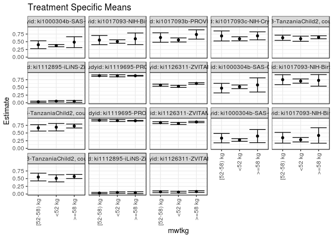

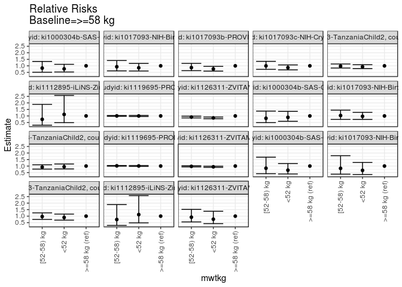

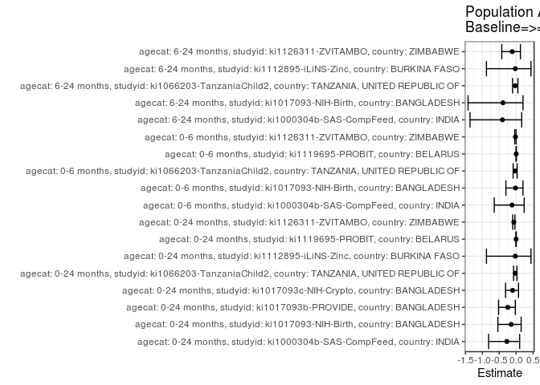

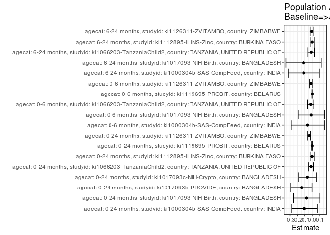

## Results Table

### Parameter: TSM

| agecat | studyid | country | intervention_level | baseline_level | estimate | ci_lower | ci_upper |
| --- | --- | --- | --- | --- | --- | --- | --- |
| 0-24 months | ki1000304b-SAS-CompFeed | INDIA | >=58 kg | NA | 0.4863505 | 0.3102797 | 0.6624213 |
| 0-24 months | ki1000304b-SAS-CompFeed | INDIA | <52 kg | NA | 0.3731407 | 0.3359352 | 0.4103462 |
| 0-24 months | ki1000304b-SAS-CompFeed | INDIA | [52-58) kg | NA | 0.4024410 | 0.2750078 | 0.5298743 |
| 0-24 months | ki1017093-NIH-Birth | BANGLADESH | >=58 kg | NA | 0.5960585 | 0.4078491 | 0.7842680 |
| 0-24 months | ki1017093-NIH-Birth | BANGLADESH | <52 kg | NA | 0.5057215 | 0.4494461 | 0.5619968 |
| 0-24 months | ki1017093-NIH-Birth | BANGLADESH | [52-58) kg | NA | 0.5544044 | 0.4052757 | 0.7035331 |
| 0-24 months | ki1017093b-PROVIDE | BANGLADESH | >=58 kg | NA | 0.7352941 | 0.5846182 | 0.8859701 |
| 0-24 months | ki1017093b-PROVIDE | BANGLADESH | <52 kg | NA | 0.5580357 | 0.4920376 | 0.6240339 |
| 0-24 months | ki1017093b-PROVIDE | BANGLADESH | [52-58) kg | NA | 0.6363636 | 0.4828843 | 0.7898430 |
| 0-24 months | ki1017093c-NIH-Crypto | BANGLADESH | >=58 kg | NA | 0.6911592 | 0.5612311 | 0.8210873 |
| 0-24 months | ki1017093c-NIH-Crypto | BANGLADESH | <52 kg | NA | 0.5950349 | 0.5290229 | 0.6610470 |
| 0-24 months | ki1017093c-NIH-Crypto | BANGLADESH | [52-58) kg | NA | 0.6876147 | 0.5257118 | 0.8495177 |
| 0-24 months | ki1066203-TanzaniaChild2 | TANZANIA, UNITED REPUBLIC OF | >=58 kg | NA | 0.6438234 | 0.5945721 | 0.6930746 |
| 0-24 months | ki1066203-TanzaniaChild2 | TANZANIA, UNITED REPUBLIC OF | <52 kg | NA | 0.5978595 | 0.5143007 | 0.6814183 |
| 0-24 months | ki1066203-TanzaniaChild2 | TANZANIA, UNITED REPUBLIC OF | [52-58) kg | NA | 0.6289758 | 0.5439521 | 0.7139996 |
| 0-24 months | ki1112895-iLiNS-Zinc | BURKINA FASO | >=58 kg | NA | 0.0446927 | 0.0135156 | 0.0758699 |
| 0-24 months | ki1112895-iLiNS-Zinc | BURKINA FASO | <52 kg | NA | 0.0500000 | 0.0272248 | 0.0727752 |
| 0-24 months | ki1112895-iLiNS-Zinc | BURKINA FASO | [52-58) kg | NA | 0.0330579 | 0.0123898 | 0.0537259 |
| 0-24 months | ki1119695-PROBIT | BELARUS | >=58 kg | NA | 0.8778981 | 0.8660539 | 0.8897424 |
| 0-24 months | ki1119695-PROBIT | BELARUS | <52 kg | NA | 0.8763080 | 0.8424421 | 0.9101739 |
| 0-24 months | ki1119695-PROBIT | BELARUS | [52-58) kg | NA | 0.8798041 | 0.8561251 | 0.9034831 |
| 0-24 months | ki1126311-ZVITAMBO | ZIMBABWE | >=58 kg | NA | 0.6267547 | 0.6005436 | 0.6529657 |
| 0-24 months | ki1126311-ZVITAMBO | ZIMBABWE | <52 kg | NA | 0.5328114 | 0.4987475 | 0.5668753 |
| 0-24 months | ki1126311-ZVITAMBO | ZIMBABWE | [52-58) kg | NA | 0.5715116 | 0.5377293 | 0.6052939 |
| 0-6 months | ki1000304b-SAS-CompFeed | INDIA | >=58 kg | NA | 0.5789474 | 0.3498480 | 0.8080467 |
| 0-6 months | ki1000304b-SAS-CompFeed | INDIA | <52 kg | NA | 0.5178571 | 0.4588483 | 0.5768660 |
| 0-6 months | ki1000304b-SAS-CompFeed | INDIA | [52-58) kg | NA | 0.4750000 | 0.3193575 | 0.6306425 |
| 0-6 months | ki1017093-NIH-Birth | BANGLADESH | >=58 kg | NA | 0.7272727 | 0.5399105 | 0.9146349 |
| 0-6 months | ki1017093-NIH-Birth | BANGLADESH | <52 kg | NA | 0.7052023 | 0.6373168 | 0.7730878 |
| 0-6 months | ki1017093-NIH-Birth | BANGLADESH | [52-58) kg | NA | 0.7500000 | 0.5885262 | 0.9114738 |
| 0-6 months | ki1066203-TanzaniaChild2 | TANZANIA, UNITED REPUBLIC OF | >=58 kg | NA | 0.7262278 | 0.6623573 | 0.7900984 |
| 0-6 months | ki1066203-TanzaniaChild2 | TANZANIA, UNITED REPUBLIC OF | <52 kg | NA | 0.6881525 | 0.5667412 | 0.8095637 |
| 0-6 months | ki1066203-TanzaniaChild2 | TANZANIA, UNITED REPUBLIC OF | [52-58) kg | NA | 0.6663269 | 0.5624334 | 0.7702204 |
| 0-6 months | ki1119695-PROBIT | BELARUS | >=58 kg | NA | 0.8982468 | 0.8869518 | 0.9095418 |
| 0-6 months | ki1119695-PROBIT | BELARUS | <52 kg | NA | 0.9033639 | 0.8721778 | 0.9345499 |
| 0-6 months | ki1119695-PROBIT | BELARUS | [52-58) kg | NA | 0.9113452 | 0.8896255 | 0.9330649 |
| 0-6 months | ki1126311-ZVITAMBO | ZIMBABWE | >=58 kg | NA | 0.8578788 | 0.8356049 | 0.8801526 |
| 0-6 months | ki1126311-ZVITAMBO | ZIMBABWE | <52 kg | NA | 0.8082190 | 0.7736763 | 0.8427616 |
| 0-6 months | ki1126311-ZVITAMBO | ZIMBABWE | [52-58) kg | NA | 0.8356762 | 0.8045176 | 0.8668348 |
| 6-24 months | ki1000304b-SAS-CompFeed | INDIA | >=58 kg | NA | 0.4000000 | 0.1876007 | 0.6123993 |
| 6-24 months | ki1000304b-SAS-CompFeed | INDIA | <52 kg | NA | 0.2733990 | 0.2292567 | 0.3175413 |
| 6-24 months | ki1000304b-SAS-CompFeed | INDIA | [52-58) kg | NA | 0.3333333 | 0.1806477 | 0.4860189 |
| 6-24 months | ki1017093-NIH-Birth | BANGLADESH | >=58 kg | NA | 0.4210526 | 0.1702652 | 0.6718400 |
| 6-24 months | ki1017093-NIH-Birth | BANGLADESH | <52 kg | NA | 0.2810458 | 0.2089924 | 0.3530991 |
| 6-24 months | ki1017093-NIH-Birth | BANGLADESH | [52-58) kg | NA | 0.3461538 | 0.1723455 | 0.5199622 |
| 6-24 months | ki1066203-TanzaniaChild2 | TANZANIA, UNITED REPUBLIC OF | >=58 kg | NA | 0.5705441 | 0.5028064 | 0.6382818 |
| 6-24 months | ki1066203-TanzaniaChild2 | TANZANIA, UNITED REPUBLIC OF | <52 kg | NA | 0.5107993 | 0.3961319 | 0.6254667 |
| 6-24 months | ki1066203-TanzaniaChild2 | TANZANIA, UNITED REPUBLIC OF | [52-58) kg | NA | 0.5522024 | 0.4272615 | 0.6771432 |
| 6-24 months | ki1112895-iLiNS-Zinc | BURKINA FASO | >=58 kg | NA | 0.0446927 | 0.0135156 | 0.0758699 |
| 6-24 months | ki1112895-iLiNS-Zinc | BURKINA FASO | <52 kg | NA | 0.0500000 | 0.0272248 | 0.0727752 |
| 6-24 months | ki1112895-iLiNS-Zinc | BURKINA FASO | [52-58) kg | NA | 0.0330579 | 0.0123898 | 0.0537259 |
| 6-24 months | ki1126311-ZVITAMBO | ZIMBABWE | >=58 kg | NA | 0.0805625 | 0.0533132 | 0.1078119 |
| 6-24 months | ki1126311-ZVITAMBO | ZIMBABWE | <52 kg | NA | 0.0615896 | 0.0321550 | 0.0910242 |
| 6-24 months | ki1126311-ZVITAMBO | ZIMBABWE | [52-58) kg | NA | 0.0739604 | 0.0464587 | 0.1014621 |

### Parameter: E(Y)

| agecat | studyid | country | intervention_level | baseline_level | estimate | ci_lower | ci_upper |
| --- | --- | --- | --- | --- | --- | --- | --- |
| 0-24 months | ki1000304b-SAS-CompFeed | INDIA | NA | NA | 0.3814815 | 0.3463355 | 0.4166275 |
| 0-24 months | ki1017093-NIH-Birth | BANGLADESH | NA | NA | 0.5201900 | 0.4695846 | 0.5707955 |
| 0-24 months | ki1017093b-PROVIDE | BANGLADESH | NA | NA | 0.5894040 | 0.5323948 | 0.6464131 |
| 0-24 months | ki1017093c-NIH-Crypto | BANGLADESH | NA | NA | 0.6258065 | 0.5718723 | 0.6797406 |
| 0-24 months | ki1066203-TanzaniaChild2 | TANZANIA, UNITED REPUBLIC OF | NA | NA | 0.6283688 | 0.5905321 | 0.6662055 |
| 0-24 months | ki1112895-iLiNS-Zinc | BURKINA FASO | NA | NA | 0.0435339 | 0.0292984 | 0.0577695 |
| 0-24 months | ki1119695-PROBIT | BELARUS | NA | NA | 0.8772681 | 0.8671551 | 0.8873812 |
| 0-24 months | ki1126311-ZVITAMBO | ZIMBABWE | NA | NA | 0.5863214 | 0.5686726 | 0.6039701 |
| 0-6 months | ki1000304b-SAS-CompFeed | INDIA | NA | NA | 0.5162242 | 0.4625356 | 0.5699128 |
| 0-6 months | ki1017093-NIH-Birth | BANGLADESH | NA | NA | 0.7130045 | 0.6535890 | 0.7724200 |
| 0-6 months | ki1066203-TanzaniaChild2 | TANZANIA, UNITED REPUBLIC OF | NA | NA | 0.7062315 | 0.6568751 | 0.7555878 |
| 0-6 months | ki1119695-PROBIT | BELARUS | NA | NA | 0.9003922 | 0.8908257 | 0.9099586 |
| 0-6 months | ki1126311-ZVITAMBO | ZIMBABWE | NA | NA | 0.8406948 | 0.8247812 | 0.8566083 |
| 6-24 months | ki1000304b-SAS-CompFeed | INDIA | NA | NA | 0.2845011 | 0.2426711 | 0.3263311 |
| 6-24 months | ki1017093-NIH-Birth | BANGLADESH | NA | NA | 0.3030303 | 0.2377927 | 0.3682679 |
| 6-24 months | ki1066203-TanzaniaChild2 | TANZANIA, UNITED REPUBLIC OF | NA | NA | 0.5570652 | 0.5044805 | 0.6096499 |
| 6-24 months | ki1112895-iLiNS-Zinc | BURKINA FASO | NA | NA | 0.0435339 | 0.0292984 | 0.0577695 |
| 6-24 months | ki1126311-ZVITAMBO | ZIMBABWE | NA | NA | 0.0722166 | 0.0562671 | 0.0881662 |

### Parameter: RR

| agecat | studyid | country | intervention_level | baseline_level | estimate | ci_lower | ci_upper |
| --- | --- | --- | --- | --- | --- | --- | --- |
| 0-24 months | ki1000304b-SAS-CompFeed | INDIA | >=58 kg | >=58 kg | 1.0000000 | 1.0000000 | 1.0000000 |
| 0-24 months | ki1000304b-SAS-CompFeed | INDIA | <52 kg | >=58 kg | 0.7672260 | 0.5270782 | 1.1167900 |
| 0-24 months | ki1000304b-SAS-CompFeed | INDIA | [52-58) kg | >=58 kg | 0.8274712 | 0.5114712 | 1.3387040 |
| 0-24 months | ki1017093-NIH-Birth | BANGLADESH | >=58 kg | >=58 kg | 1.0000000 | 1.0000000 | 1.0000000 |
| 0-24 months | ki1017093-NIH-Birth | BANGLADESH | <52 kg | >=58 kg | 0.8484426 | 0.6068437 | 1.1862277 |
| 0-24 months | ki1017093-NIH-Birth | BANGLADESH | [52-58) kg | >=58 kg | 0.9301174 | 0.6142705 | 1.4083670 |
| 0-24 months | ki1017093b-PROVIDE | BANGLADESH | >=58 kg | >=58 kg | 1.0000000 | 1.0000000 | 1.0000000 |
| 0-24 months | ki1017093b-PROVIDE | BANGLADESH | <52 kg | >=58 kg | 0.7589286 | 0.5989095 | 0.9617023 |
| 0-24 months | ki1017093b-PROVIDE | BANGLADESH | [52-58) kg | >=58 kg | 0.8654545 | 0.6305508 | 1.1878687 |
| 0-24 months | ki1017093c-NIH-Crypto | BANGLADESH | >=58 kg | >=58 kg | 1.0000000 | 1.0000000 | 1.0000000 |
| 0-24 months | ki1017093c-NIH-Crypto | BANGLADESH | <52 kg | >=58 kg | 0.8609231 | 0.6915300 | 1.0718097 |
| 0-24 months | ki1017093c-NIH-Crypto | BANGLADESH | [52-58) kg | >=58 kg | 0.9948717 | 0.7357012 | 1.3453418 |
| 0-24 months | ki1066203-TanzaniaChild2 | TANZANIA, UNITED REPUBLIC OF | >=58 kg | >=58 kg | 1.0000000 | 1.0000000 | 1.0000000 |
| 0-24 months | ki1066203-TanzaniaChild2 | TANZANIA, UNITED REPUBLIC OF | <52 kg | >=58 kg | 0.9286080 | 0.7917658 | 1.0891009 |
| 0-24 months | ki1066203-TanzaniaChild2 | TANZANIA, UNITED REPUBLIC OF | [52-58) kg | >=58 kg | 0.9769385 | 0.8363441 | 1.1411677 |
| 0-24 months | ki1112895-iLiNS-Zinc | BURKINA FASO | >=58 kg | >=58 kg | 1.0000000 | 1.0000000 | 1.0000000 |
| 0-24 months | ki1112895-iLiNS-Zinc | BURKINA FASO | <52 kg | >=58 kg | 1.1187500 | 0.4863026 | 2.5737094 |
| 0-24 months | ki1112895-iLiNS-Zinc | BURKINA FASO | [52-58) kg | >=58 kg | 0.7396694 | 0.2898718 | 1.8874236 |
| 0-24 months | ki1119695-PROBIT | BELARUS | >=58 kg | >=58 kg | 1.0000000 | 1.0000000 | 1.0000000 |
| 0-24 months | ki1119695-PROBIT | BELARUS | <52 kg | >=58 kg | 0.9981887 | 0.9581473 | 1.0399036 |
| 0-24 months | ki1119695-PROBIT | BELARUS | [52-58) kg | >=58 kg | 1.0021711 | 0.9724388 | 1.0328124 |
| 0-24 months | ki1126311-ZVITAMBO | ZIMBABWE | >=58 kg | >=58 kg | 1.0000000 | 1.0000000 | 1.0000000 |
| 0-24 months | ki1126311-ZVITAMBO | ZIMBABWE | <52 kg | >=58 kg | 0.8501116 | 0.7875492 | 0.9176439 |
| 0-24 months | ki1126311-ZVITAMBO | ZIMBABWE | [52-58) kg | >=58 kg | 0.9118586 | 0.8481388 | 0.9803655 |
| 0-6 months | ki1000304b-SAS-CompFeed | INDIA | >=58 kg | >=58 kg | 1.0000000 | 1.0000000 | 1.0000000 |
| 0-6 months | ki1000304b-SAS-CompFeed | INDIA | <52 kg | >=58 kg | 0.8944805 | 0.5925569 | 1.3502424 |
| 0-6 months | ki1000304b-SAS-CompFeed | INDIA | [52-58) kg | >=58 kg | 0.8204545 | 0.4908259 | 1.3714550 |
| 0-6 months | ki1017093-NIH-Birth | BANGLADESH | >=58 kg | >=58 kg | 1.0000000 | 1.0000000 | 1.0000000 |
| 0-6 months | ki1017093-NIH-Birth | BANGLADESH | <52 kg | >=58 kg | 0.9696532 | 0.7365063 | 1.2766045 |
| 0-6 months | ki1017093-NIH-Birth | BANGLADESH | [52-58) kg | >=58 kg | 1.0312500 | 0.7371449 | 1.4426967 |
| 0-6 months | ki1066203-TanzaniaChild2 | TANZANIA, UNITED REPUBLIC OF | >=58 kg | >=58 kg | 1.0000000 | 1.0000000 | 1.0000000 |
| 0-6 months | ki1066203-TanzaniaChild2 | TANZANIA, UNITED REPUBLIC OF | <52 kg | >=58 kg | 0.9475711 | 0.7781762 | 1.1538401 |
| 0-6 months | ki1066203-TanzaniaChild2 | TANZANIA, UNITED REPUBLIC OF | [52-58) kg | >=58 kg | 0.9175177 | 0.7672544 | 1.0972095 |
| 0-6 months | ki1119695-PROBIT | BELARUS | >=58 kg | >=58 kg | 1.0000000 | 1.0000000 | 1.0000000 |
| 0-6 months | ki1119695-PROBIT | BELARUS | <52 kg | >=58 kg | 1.0056967 | 0.9694134 | 1.0433381 |
| 0-6 months | ki1119695-PROBIT | BELARUS | [52-58) kg | >=58 kg | 1.0145822 | 0.9876050 | 1.0422962 |
| 0-6 months | ki1126311-ZVITAMBO | ZIMBABWE | >=58 kg | >=58 kg | 1.0000000 | 1.0000000 | 1.0000000 |
| 0-6 months | ki1126311-ZVITAMBO | ZIMBABWE | <52 kg | >=58 kg | 0.9421132 | 0.8961384 | 0.9904467 |
| 0-6 months | ki1126311-ZVITAMBO | ZIMBABWE | [52-58) kg | >=58 kg | 0.9741192 | 0.9308359 | 1.0194152 |
| 6-24 months | ki1000304b-SAS-CompFeed | INDIA | >=58 kg | >=58 kg | 1.0000000 | 1.0000000 | 1.0000000 |
| 6-24 months | ki1000304b-SAS-CompFeed | INDIA | <52 kg | >=58 kg | 0.6834975 | 0.3923772 | 1.1906117 |
| 6-24 months | ki1000304b-SAS-CompFeed | INDIA | [52-58) kg | >=58 kg | 0.8333333 | 0.4133009 | 1.6802394 |
| 6-24 months | ki1017093-NIH-Birth | BANGLADESH | >=58 kg | >=58 kg | 1.0000000 | 1.0000000 | 1.0000000 |
| 6-24 months | ki1017093-NIH-Birth | BANGLADESH | <52 kg | >=58 kg | 0.6674837 | 0.3488386 | 1.2771937 |
| 6-24 months | ki1017093-NIH-Birth | BANGLADESH | [52-58) kg | >=58 kg | 0.8221154 | 0.3772729 | 1.7914718 |
| 6-24 months | ki1066203-TanzaniaChild2 | TANZANIA, UNITED REPUBLIC OF | >=58 kg | >=58 kg | 1.0000000 | 1.0000000 | 1.0000000 |
| 6-24 months | ki1066203-TanzaniaChild2 | TANZANIA, UNITED REPUBLIC OF | <52 kg | >=58 kg | 0.8952845 | 0.6944021 | 1.1542799 |
| 6-24 months | ki1066203-TanzaniaChild2 | TANZANIA, UNITED REPUBLIC OF | [52-58) kg | >=58 kg | 0.9678522 | 0.7495341 | 1.2497602 |
| 6-24 months | ki1112895-iLiNS-Zinc | BURKINA FASO | >=58 kg | >=58 kg | 1.0000000 | 1.0000000 | 1.0000000 |
| 6-24 months | ki1112895-iLiNS-Zinc | BURKINA FASO | <52 kg | >=58 kg | 1.1187500 | 0.4863026 | 2.5737094 |
| 6-24 months | ki1112895-iLiNS-Zinc | BURKINA FASO | [52-58) kg | >=58 kg | 0.7396694 | 0.2898718 | 1.8874236 |
| 6-24 months | ki1126311-ZVITAMBO | ZIMBABWE | >=58 kg | >=58 kg | 1.0000000 | 1.0000000 | 1.0000000 |
| 6-24 months | ki1126311-ZVITAMBO | ZIMBABWE | <52 kg | >=58 kg | 0.7644941 | 0.4255014 | 1.3735588 |
| 6-24 months | ki1126311-ZVITAMBO | ZIMBABWE | [52-58) kg | >=58 kg | 0.9180492 | 0.5552976 | 1.5177706 |

### Parameter: PAR

| agecat | studyid | country | intervention_level | baseline_level | estimate | ci_lower | ci_upper |
| --- | --- | --- | --- | --- | --- | --- | --- |
| 0-24 months | ki1000304b-SAS-CompFeed | INDIA | >=58 kg | NA | -0.1048690 | -0.2763224 | 0.0665844 |
| 0-24 months | ki1017093-NIH-Birth | BANGLADESH | >=58 kg | NA | -0.0758685 | -0.2529329 | 0.1011959 |
| 0-24 months | ki1017093b-PROVIDE | BANGLADESH | >=58 kg | NA | -0.1458901 | -0.2895446 | -0.0022357 |
| 0-24 months | ki1017093c-NIH-Crypto | BANGLADESH | >=58 kg | NA | -0.0653528 | -0.1846707 | 0.0539652 |
| 0-24 months | ki1066203-TanzaniaChild2 | TANZANIA, UNITED REPUBLIC OF | >=58 kg | NA | -0.0154546 | -0.0470243 | 0.0161152 |
| 0-24 months | ki1112895-iLiNS-Zinc | BURKINA FASO | >=58 kg | NA | -0.0011588 | -0.0281611 | 0.0258435 |
| 0-24 months | ki1119695-PROBIT | BELARUS | >=58 kg | NA | -0.0006300 | -0.0067524 | 0.0054924 |
| 0-24 months | ki1126311-ZVITAMBO | ZIMBABWE | >=58 kg | NA | -0.0404333 | -0.0597413 | -0.0211252 |
| 0-6 months | ki1000304b-SAS-CompFeed | INDIA | >=58 kg | NA | -0.0627232 | -0.2851766 | 0.1597303 |
| 0-6 months | ki1017093-NIH-Birth | BANGLADESH | >=58 kg | NA | -0.0142682 | -0.1923365 | 0.1638001 |
| 0-6 months | ki1066203-TanzaniaChild2 | TANZANIA, UNITED REPUBLIC OF | >=58 kg | NA | -0.0199964 | -0.0618035 | 0.0218107 |
| 0-6 months | ki1119695-PROBIT | BELARUS | >=58 kg | NA | 0.0021454 | -0.0034780 | 0.0077687 |
| 0-6 months | ki1126311-ZVITAMBO | ZIMBABWE | >=58 kg | NA | -0.0171840 | -0.0340384 | -0.0003296 |
| 6-24 months | ki1000304b-SAS-CompFeed | INDIA | >=58 kg | NA | -0.1154989 | -0.3229953 | 0.0919975 |
| 6-24 months | ki1017093-NIH-Birth | BANGLADESH | >=58 kg | NA | -0.1180223 | -0.3533429 | 0.1172982 |
| 6-24 months | ki1066203-TanzaniaChild2 | TANZANIA, UNITED REPUBLIC OF | >=58 kg | NA | -0.0134789 | -0.0570459 | 0.0300882 |
| 6-24 months | ki1112895-iLiNS-Zinc | BURKINA FASO | >=58 kg | NA | -0.0011588 | -0.0281611 | 0.0258435 |
| 6-24 months | ki1126311-ZVITAMBO | ZIMBABWE | >=58 kg | NA | -0.0083459 | -0.0282324 | 0.0115406 |

### Parameter: PAF

| agecat | studyid | country | intervention_level | baseline_level | estimate | ci_lower | ci_upper |
| --- | --- | --- | --- | --- | --- | --- | --- |
| 0-24 months | ki1000304b-SAS-CompFeed | INDIA | >=58 kg | NA | -0.2748994 | -0.8136631 | 0.1038200 |
| 0-24 months | ki1017093-NIH-Birth | BANGLADESH | >=58 kg | NA | -0.1458477 | -0.5409776 | 0.1479649 |
| 0-24 months | ki1017093b-PROVIDE | BANGLADESH | >=58 kg | NA | -0.2475215 | -0.5202035 | -0.0237510 |
| 0-24 months | ki1017093c-NIH-Crypto | BANGLADESH | >=58 kg | NA | -0.1044297 | -0.3130109 | 0.0710169 |
| 0-24 months | ki1066203-TanzaniaChild2 | TANZANIA, UNITED REPUBLIC OF | >=58 kg | NA | -0.0245947 | -0.0761123 | 0.0244565 |
| 0-24 months | ki1112895-iLiNS-Zinc | BURKINA FASO | >=58 kg | NA | -0.0266185 | -0.8777261 | 0.4387118 |
| 0-24 months | ki1119695-PROBIT | BELARUS | >=58 kg | NA | -0.0007181 | -0.0077214 | 0.0062365 |
| 0-24 months | ki1126311-ZVITAMBO | ZIMBABWE | >=58 kg | NA | -0.0689609 | -0.1024630 | -0.0364769 |
| 0-6 months | ki1000304b-SAS-CompFeed | INDIA | >=58 kg | NA | -0.1215038 | -0.6471022 | 0.2363736 |
| 0-6 months | ki1017093-NIH-Birth | BANGLADESH | >=58 kg | NA | -0.0200114 | -0.3030056 | 0.2015204 |
| 0-6 months | ki1066203-TanzaniaChild2 | TANZANIA, UNITED REPUBLIC OF | >=58 kg | NA | -0.0283142 | -0.0893367 | 0.0292900 |
| 0-6 months | ki1119695-PROBIT | BELARUS | >=58 kg | NA | 0.0023827 | -0.0038835 | 0.0086097 |
| 0-6 months | ki1126311-ZVITAMBO | ZIMBABWE | >=58 kg | NA | -0.0204402 | -0.0407207 | -0.0005549 |
| 6-24 months | ki1000304b-SAS-CompFeed | INDIA | >=58 kg | NA | -0.4059701 | -1.3642228 | 0.1638893 |
| 6-24 months | ki1017093-NIH-Birth | BANGLADESH | >=58 kg | NA | -0.3894737 | -1.4221313 | 0.2029181 |
| 6-24 months | ki1066203-TanzaniaChild2 | TANZANIA, UNITED REPUBLIC OF | >=58 kg | NA | -0.0241962 | -0.1055440 | 0.0511659 |
| 6-24 months | ki1112895-iLiNS-Zinc | BURKINA FASO | >=58 kg | NA | -0.0266185 | -0.8777261 | 0.4387118 |
| 6-24 months | ki1126311-ZVITAMBO | ZIMBABWE | >=58 kg | NA | -0.1155675 | -0.4246367 | 0.1264504 |